# A Comparative Analysis of Historical Pandemics through Data Visualization

INFO 526 - Fall 2024 - Project 02

Author

Affiliation

Epidata

College of Information, University of Arizona

## Introduction

The main goal of this project is to dive deeper into some significant pandemics from human history, including Cholera, Dengue, and COVID-19. We are aware, to some extent, of the fact that these pandemics caused great loss and profoundly impacted human society in numerous ways, but we have no deeper understanding of them. Therefore, we want to use data visualizations to visually present and explore the similarities and differences among these pandemics or diseases that happened on a large scale in different time periods.

## Background

- Cholera is an infectious disease that is spread by eating food or drinking water contaminated by already infected people. This disease typically has outbreaks in regions with poor sanitation.
- Dengue is a disease transmitted by Aedes mosquitoes that bite people infected with dengue virus. This disease is particularly rampant in tropical and subtropical regions.
- COVID-19 is a highly contagious respiratory illness caused by the SARS-CoV-2 virus. The pandemics started in late 2019 and declared over in May 2023.

## Datasets

Three original datasets were used in this project: [Cholera](https://worldhealthorg.shinyapps.io/page10cholera_data/), [Dengue](https://worldhealthorg.shinyapps.io/dengue_global/), and [COVID-19](https://data.who.int/dashboards/covid19/data), all obtained from World Health Organization (WHO) website. The data wrangling steps for each task can be viewed in the *extras* folder. The variable information of the original datasets are displayed below.

The [Cholera dataset](https://worldhealthorg.shinyapps.io/page10cholera_data/) includes annual country-level data on cases, mortality, and incidence rates from 2000 to 2023, with key columns such as Country, Region, Year, Total Cases, Deaths, and Case Fatality Rate (CFR). This dataset consists of 1,094 rows and 12 columns of records.

| **Variable** | **Type** | **Description** |
| --- | --- | --- |
| Country | Character | Name of the country where cases are reported |
| GTFCC_Target_Country | Character | Indicates whether the country is a target of the Global Task Force on Cholera Control (GTFCC) |
| Continent | Character | Continent to which the country belongs |
| WHO_Region | Character | World Health Organization(WHO) regional classification of the country |
| Subregion | Character | Subregional classification within the WHO region |
| Year | Numeric | Year in which the cases were recorded |
| Total_Cases | Numeric | Total number of cholera cases reported |
| Autochtonous_Cases | Numeric | Number of cholera cases originating within the country |
| Imported_Cases | Numeric | Number of cholera cases imported from other countries |
| Deaths | Numeric | Number of deaths caused by cholera |
| CFR | Numeric | Case Fatality rate, representing the percentage of cases that resulted in death |
| Incidence_Rate_perMillion | Numeric | Cholera incidence rate per million people |

The [Dengue Fever dataset](https://worldhealthorg.shinyapps.io/dengue_global/) contains monthly case data by country from January 1, 2010, to September 1, 2024, capturing metrics on severe cases, deaths, and fatality rates, and providing information across multiple dimensions, including date, region, country, and case severity. This dataset consists of 7,862 rows and 16 columns of records.

| **Variable** | **Type** | **Description** |
| --- | --- | --- |
| date | Numeric | Date of entried record |
| date_lab | Character | Date displayed in string |
| who_region | Character | World Health Organisation (WHO) region code |
| who_region_long | Character | Complete name of the WHO region |
| country | Character | Name of the country |
| iso3 | Character | This represents the ISO3 country code |
| cases | Numeric | Total number of reported cases |
| confirmed_cases | Numeric | Total number of confirmed cases |
| severe_cases | Numeric | The number of newly reported several cases |
| deaths | Numeric | The number of newly reported deaths |
| cfr | Numeric | Case fatality ratio (CFR) is the ratio of the total number of deaths to the total number of cases in the same period |
| prop_sev | Numeric | Proportion of severe cases is the ratio of the total number of severe cases to the total number of cases in the same period |
| cfr_ci_lower | Numeric | The lower bound of confidence interval of case fatality ratio |
| cfr_ci_upper | Numeric | The upper bound of confidence interval of fatality ratio |
| prop_sev_ci_lower | Numeric | The lower bound of confidence interval of proportion of severe cases |
| prop_sev_ci_upper | Numeric | The upper bound of confidence interval of proportion of severe cases |

The [COVID-19 dataset](https://data.who.int/dashboards/covid19/data) provides daily reported cases and deaths at the country level from January 4, 2020, to September 22, 2024, offering a detailed timeline of the pandemic’s progression across regions. This dataset consists of 422,160 rows and 8 columns of records.

| **Variable** | **Type** | **Description** |
| --- | --- | --- |
| Date_reported | Character | The date on which the data was reported in YYYY-MM-DD format |
| Country_code | Character | The ISO code of the country |
| Country | Character | Full name of the country |
| WHO_region | Character | WHO region classification of the country |
| New_cases | Numeric | The number of new COVID-19 cases reported on the given date |
| Cumulative_cases | Numeric | The total number of COVID-19 cases reported up to the given date |
| New_deaths | Numeric | The number of new COVID-19 deaths reported on the given date |
| Cumulative_deaths | Numeric | The total number of COVID-19 deaths reported up to the given date |

## Exploration

### Question 1: What are the number of total cases and death counts over time?

#### Introduction

We wanted to explore the trends of both total cases and death counts with time for all three pandemics, so we chose to use stream graphs to visualize the information, because stream graphs are useful and effective to visualize time series data of two different but related variables.

#### Approach

To process the data and get the information for this task, we aggregated each dataset grouping by time (by Year for Cholera dataset, and by Year-Month for both Dengue and COVID-19 datasets) and obtained the numbers of total cases and death counts for each time period. Then we used ggplot to plot the information, specifically using “geom_area”.

For all three graphs, the upper parts display the number of death counts with color red, the lower parts display the number of total cases with color blue, and the horizontal axes are the timelines. The start and the end values of the horizontal axes are different for each graph, because the original datasets collected the records from different time periods. The Cholera dataset contains information from the year 2000 to year 2023; the Dengue dataset contains information from January 1, 2010 to September 1, 2024; the COVID-19 dataset contains information from January 4, 2020 to September 22, 2024.

Since the number of death counts are in small proportions to the number of total cases for all three datasets, the upper parts of the stream graphs are not as observable as the lower parts. Therefore, the annotation texts were added to the graphs, denoting the highest several death counts along with the corresponding time.

#### Analysis

The stream graphs produced in the project are displayed below.

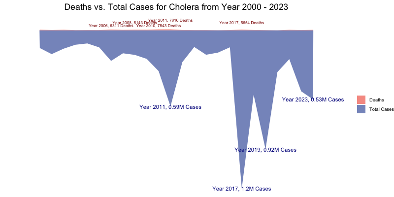

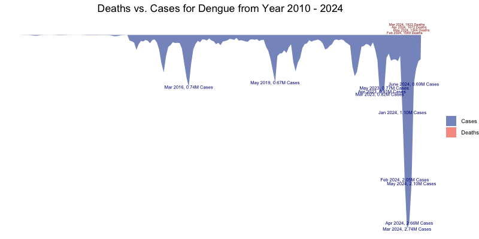

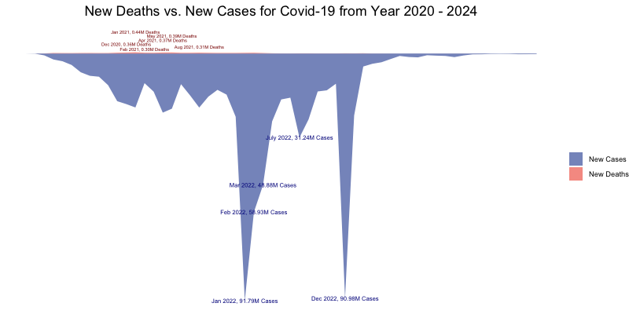

From the graphs above, we can observe that,

- For Cholera, the biggest outbreaks happened around the years 2017 and 2019. Before these two periods, 2011 was the first huge outbreak, which had 0.59 million total cases as well as having the highest death counts. The outbreaks of Cholera are highly related to the contamination of water sources, so the regions with poor sanitation during years with disastrous flooding are the main sites of Cholera infections.
- For Dengue, the biggest outbreaks happened in 2024, from January to June. The peak was in March 2024, having 2.74 million total cases in the month, and also having the most death counts. Dengue could be seasonal, because it’s mostly late spring to early summer that had the pandemic waves. It is highly likely due to the propagation of Aedes mosquitoes, which are responsible for the spread of the dengue pandemics.
- For COVID-19, December 2020 to August 2021 had horrendous amounts of deaths, and then gradually decreased to a lower level. It may be due to the prevalence of vaccine access and quarantine measures taken into effect around the world. The total cases, however, had spikes in January 2022 and December 2022. The reasons may include the end of quarantine for most regions.

### Question 2: How did each pandemic spread geographically?

#### Introduction

Understanding the geographical spread of pandemics is crucial for effective public health interventions and global disease prevention. Cholera, dengue, and COVID-19, while differing in transmission methods, provide valuable insights into how infectious diseases propagate across regions.Analyzing the spatial patterns of these diseases highlights the factors influencing their transmission and informs strategies for future outbreak containment.

#### Approach

We pre-processed data for COVID-19, cholera, and dengue by renaming columns, standardizing dates, and ensuring consistent data types across datasets.Then aggregated case counts yearly and cumulatively for each country to generate combined datasets for each disease. As we are plotting our visualization on a world map from “rnaturalearth” package we ensured that country names were standardized and match the geographic boundaries in the world map data.

All three datasets were merged into a single dataset, adding a column to identify the disease and its case counts. This combined dataset was joined with spatial data from Natural Earth to prepare for mapping. Using Shiny, we built an interactive UI that lets users select diseases and years, and a heatmap was created with ggplot2 to show-case distribution by region.

The heatmaps showcase the relative intensity of the outbreaks, with darker shades indicating higher concentrations of reported cases. This allows for a quick and intuitive understanding of how the diseases have spread and which regions have been most heavily impacted.

#### Analysis

We have calculated yearly and cummulative cases for each disease and visualized the geographical spread of the data across all years and explored how this spread changes when filtered by specific years, providing insights into the temporal and geographical variations.

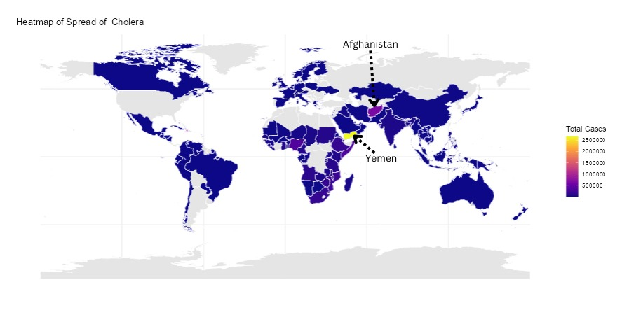

Heat Map of Cholera

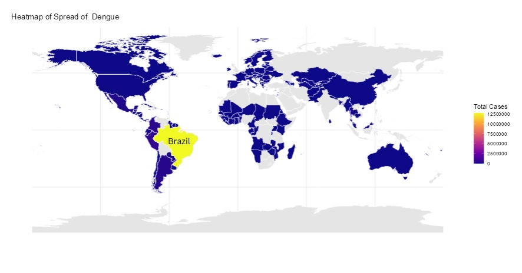

Heat Map of Dengue

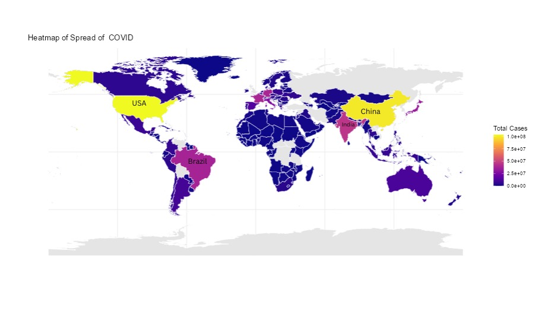

Heat Map of COVID

The COVID-19 heatmap (the third image in this subsection) shows a true global pandemic, with intense outbreaks occurring across North America, Europe, and parts of Asia. The speckled distribution suggests the rapid and widespread transmission of the virus, highlighting the challenges of containing a highly contagious respiratory disease.

Note: The text indicating places in the map has been added externally for easy analysis.

#### Temporal Trends

##### COVID-19 (2020-2024)

- **Early 2020**: The **United States** and **China** were the first major countries to experience significant outbreaks with **the U.S.** becoming the global epicenter by the end of the year.
- **2021**: Countries like **India** and **Brazil** faced severe surges.
- **2022-2023**: After vaccination rollouts, most **European** and **North American** countries saw a decline in cases. However, **China** saw a sharp spike in late 2022,
- **2024**: As COVID-19 cases generally decreased globally, countries like **China** and **Brazil** still had occasional surges

##### Dengue (2010-2024)

- **2010-2014**: Countries like **Brazil** onsistently reported dengue outbreaks.
- **2015-2019**: There was an upward trend in cases in **Sri Lanka**, **Philippines**, and **Brazil**, with **Sri Lanka** experiencing its worst outbreak in 2017.
- **2020-2021**: The pandemic lockdowns caused a temporary decline in cases globally.
- **2023-2024**: The number of dengue cases reached an all-time high in countries like the **Philippines**, where over **400,000** cases were reported in a single year, indicating a sharp increase.

##### Cholera (2000-2024)

- **2000-2010**: **Haiti**, **Bangladesh**, and **India** experienced recurring cholera outbreaks,
- **2011-2015**: During this period, **Yemen** saw the emergence of new outbreaks, especially in **2014**. The disease remained endemic in parts of **South Asia** and **Africa**.
- **2016-2020**: The largest outbreak occurred in **Yemen** from 2016 to 2018.
- **2021-2024**: **Haiti** saw a resurgence in **2022-2023**, marking a new peak after years of decline.

#### Discussion

The visualizations provide a valuable overview of how these pandemics have unfolded on a global scale. The differences in the spatial patterns observed can be attributed to factors such as the modes of disease transmission, the availability of preventive measures, and the effectiveness of public health interventions.

By analyzing these heatmaps, policymakers and public health officials can identify areas of high risk and prioritize resource allocation and targeted interventions. Additionally, the insights gained from this analysis can inform the development of early warning systems, the enhancement of disease surveillance, and the creation of more resilient healthcare systems.

### Question 3: Is there a correlation between the releases of news articles reporting COVID-19 and the spread speed of COVID-19?

#### Introduction

Our objective in Task 3 was using time series to see the disease growth rate and understand the changes in disease growth rate after the relative news reports at the first beginning of the COVID-19 pandemic. So here we chose to use a mixture of a line graph and a histogram to display the number of monthly COVID-19 cases and the number of news articles. This plot could show the trend clearly, allowing us to see local decline or growth and displaying the contrast. Only COVID-19 was chosen here because COVID-19 is the most recent and largest pandemic with plenty of news sources, so we could explore potential patterns.

#### Approach

From September 2020 onwards, the trend of the covid-19 outbreak could be characterized by a “second wave”, especially in the introduction of tougher bordering restrictions, and the surge in the number of cases. At the same time, several media reports also reported that it was the beginning of the second wave of the pandemic. Therefore, we chose to filter news about COVID-19 through September 2020. The news data was obtained from Multidisciplinary Digital Publishing Institute (MDPI). News was collected by Web Scraper through Rstudio. Here we get 3155 news in total which covers the whole year of 2020, because we are looking at the early stages of the outbreak and the impact of the news on it. So here we only choose news up to September 2020. The website of news is in the reference section.

The plot is displayed below.

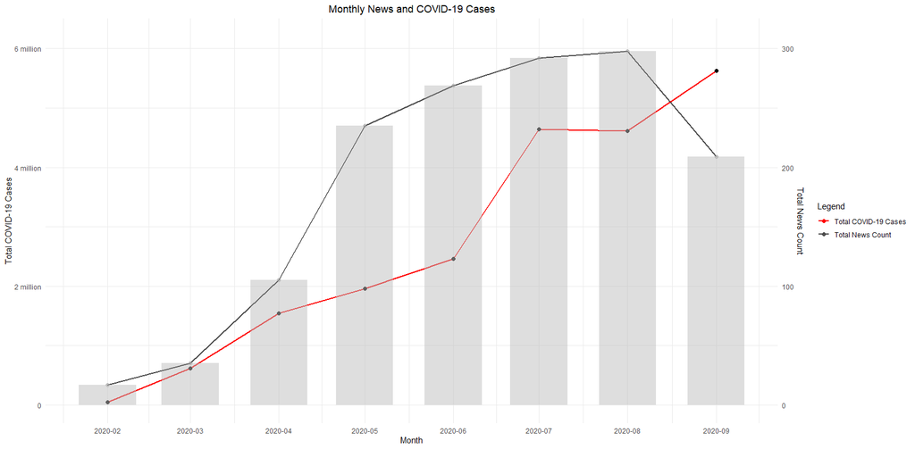

Correlation between News Articles Releases and COVID-19 Spread

The gray bars and gray line display the number of monthly news articles about COVID-19, while its axis corresponds to the right y-axis. The red line represents the total cases of covid-19 and corresponds to the left y-axis. (Note: Two y-axes are used here, so please be careful to distinguish between them.)

#### Analysis

From the graph we can see that when the number of news increases significantly, the growth of new infectious cases slows down. From the table you can see below, most notably from April to May 2020. You can check the information in the table below. The growth rate in the news releases in April (123.81%) is significantly higher than the new infectious cases’ growth rate (26.34%). Meanwhile, the growth rate of news releases was only 8.55% from June to July, which means it increased very slowly, so that the new infectious cases increased extremely rapidly, approximately 89.01% from June to July 2020. This interesting phenomenon may also suggest that the news releases in the early stages of the pandemic were inversely correlated to the new infectious cases to some extent.

| **Month** | **News Growth Rate** | **COVID-19 Cases Growth Rate** |
| --- | --- | --- |
| 2020-03-01 | 105.88 | 1223.20 |
| 2020-04-01 | 200.00 | 152.03 |
| 2020-05-01 | 123.81 | 26.34 |
| 2020-06-01 | 14.47 | 25.61 |
| 2020-07-01 | 8.55 | 89.01 |
| 2020-08-01 | 2.05 | -0.69 |
| 2020-09-01 | -29.87 | 22.15 |

### Question 4: What are the differences in the disease manifestation among three pandemics, specifically in incubation period, mortality rate, and illness duration?

#### Introduction

This task aims to explore the differences in the manifestation of Cholera, Dengue, and COVID-19 by analyzing their incubation periods, mortality rates, and illness durations. These metrics provide essential insights into the behavior of each disease, helping public health officials understand their spread, severity, and impact. By using data visualization, specifically radar charts, this analysis displays how these pandemics differ in their characteristics and emphasizes the need for responses to mitigate their effects on societies.

#### Approach

To perform this analysis, data was sourced from the World Health Organization (WHO) datasets for Cholera, Dengue, and COVID-19. After cleaning and standardizing the data, key metrics were selected for comparison. The incubation period represents the time between exposure to the pathogen and the onset of symptoms. Mortality rate captures the proportion of cases resulting in death, and illness duration reflects the average recovery period for infected individuals. Radar charts were chosen as the visualization method for this task because they provide a clear and comparative representation of these metrics across the three pandemics. A combined radar chart was used to highlight the differences between all three diseases simultaneously, while individual charts were created to focus on the specific characteristics of each pandemic.

The plots are displayed below.

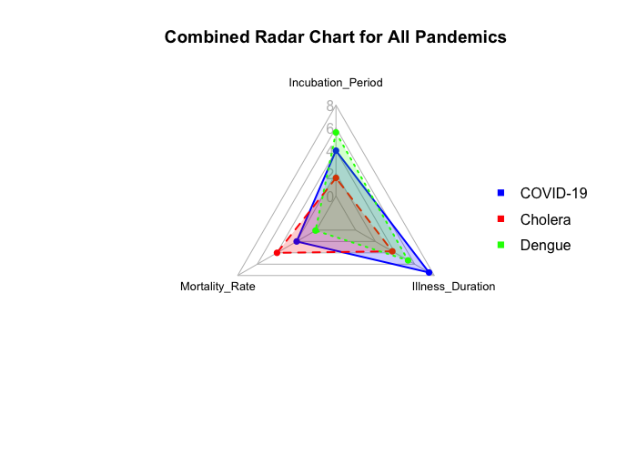

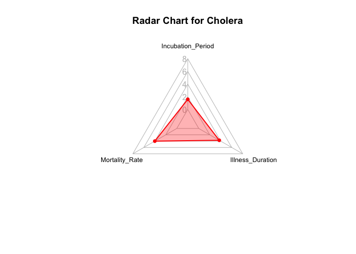

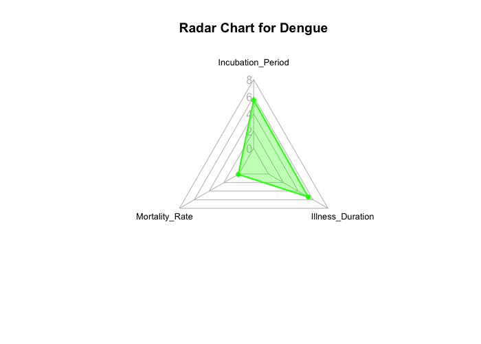

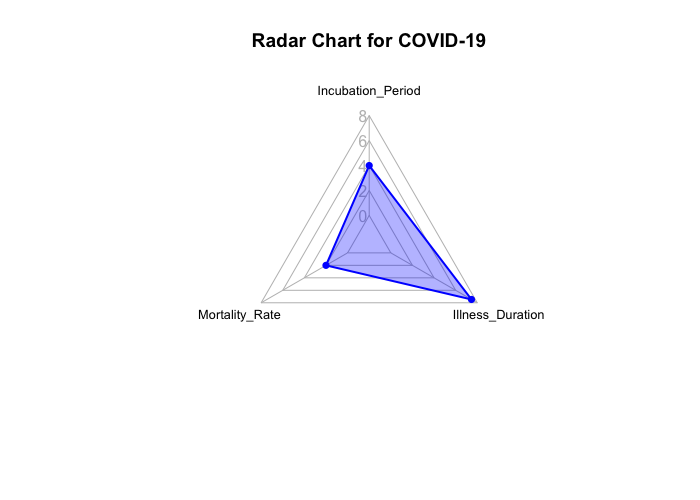

## Conclusion

Different epidemics have different types of outbreaks. Dengue pandemics occurred seasonally, mostly late spring to early summer. This is likely due to the propogation of Aedes mosquitoes during these periods, which are responsible for the spread of the dengue pandemics. Cholera epidemics outbreaks are closely related to contamination of water sources, which is associated with years with heavy rainfall and flooding. COVID-19 had higher mortality rate at the early stage of pandemics than at the late stage, likely due to the vaccine access at the late stage; the total infected cases had spiked at the late stage, likely due to the end of quarantine measure.

Ultimately, this project demonstrates the power of data visualization in enhancing our understanding of global health challenges. By leveraging these insights, we can better prepare for and respond to future pandemics, ultimately improving the well-being of communities around the world.

## Future Directions

We can emphasize on the time stamps of each pandemics where there were huge outbreaks, and research on the reasons behind them.

We can also research on pandemics other than Cholera, Dengue and COVID-19, and compare the results to find the differences and similarities. Summarize the methods to try to provide suggestions on efficiently containing the spread of pandemics.

## References

- Cholera dataset: https://worldhealthorg.shinyapps.io/page10cholera_data/
- Dengue dataset: https://worldhealthorg.shinyapps.io/dengue_global/
- COVID-19 dataset: https://data.who.int/dashboards/covid19/data
- CNN news: https://www.cnn.com/2020/09/19/europe/europe-second-wave-coronavirus-intl/index.html
- CBSNEWS: https://www.cbsnews.com/news/covid-cases-in-uk-surge-as-britain-and-other-european-nations-face-possible-second-lockdowns/
- Samina Amin, Muhammad Ali Zeb, Hani Alshahrani, Mohammed Hamdi, Mohammad Alsulami, Asadullah Shaikh. Social Media-Based Surveillance Systems for Health Informatics Using Machine and Deep Learning Techniques: A Comprehensive Review and Open Challenges. CMES - Computer Modeling in Engineering and Sciences, Volume 139, Issue 2, 2024, Pages 1167-1202, ISSN 1526-1492, https://doi.org/10.32604/cmes.2023.043921. (https://www.sciencedirect.com/science/article/pii/S152614922400198X)
- The website of news: https://www.mdpi.com/search?sort=pubdate&page_no=14&page_count=200&year_from=2020&year_to=2020&q=Covid&view=compact